# Tool info

De Stationsradar bouwt methodologisch verder op de meest recente ontwikkelingen binnen de wetenschappelijke literatuur m.b.t. **knoop-plaatsanalyses**, en meer specifiek op de **stationsevaluatiemodellen** die recent zijn doorontwikkeld op basis van het knoop-plaatsmodel (denk aan het ‘vlindermodel’, het ‘vliegermodel’, het knoop-plaatsdiagram en andere).

De tool brengt een **grote hoeveelheid informatie** samen die een **stand van zaken** geeft over de bereikbaarheid van het station en zijn omgeving, én de gebruikers van het station. Deze data is afkomstig van verschillende instanties (de vervoersmaatschappijen NMBS, De Lijn, MIVB/STIB en TEC, maar ook VITO, de provincies, OpenStreetMap e.a.). Op basis van zoveel mogelijk bestaande bronnen en eerder uitgevoerde studies werden zodoende **de huidige kwaliteiten van de knooppunten** zo grondig mogelijk in kaart gebracht. De stationsradar focust specifiek op treinstations, maar de verschillende kaartlagen die zijn opgenomen zijn gebiedsdekkend en bieden op die manier ook informatie over de bereikbaarheid van plekken die zich buiten het stationsgebied bevinden. In lijn met eerdere studies wordt het stationsgebied hier beschouwd als het gebied dat binnen een **kwartier wandelen** via het begaanbare wegennetwerk bereikt kan worden (een afstand van 1200 meter).

De aanpak is zowel inventariserend als analyserend, en waardeert de stations **ten opzichte van elkaar** in het treinnetwerk. Dit houdt in dat de score van een bepaald station op een bepaalde eigenschap (bv. aantal gratis fietsparkeerplaatsen), steeds relatief ten opzichte van de scores van alle andere stations wordt bekeken en gevisualiseerd in het diagram. Alle scores worden bovendien herschaald op een as variërend van 0 tot 10. Er zal voor elke eigenschap dan ook steeds een station zijn met de minimale score 0, en een station met de maximale score 10. Deze aanpak laat toe om de **relatieve sterktes en zwaktes** van een aantal stations binnen een regionale context op een snelle en eenvoudige manier te interpreteren.

De scores worden gevisualiseerd in een **roosdiagram** (zie figuur onder). Het diagram is opgebouwd uit **twee helften**, waarbij de bovenste helft alle informatie bevat die ook in de standaard knoop-plaats modellen is opgenomen, en dus betrekking heeft op de bereikbaarheid van het station en de eigenschappen van de stationsbuurt. De onderste helft van het diagram is een eigen toevoeging aan het knoop-plaatsmodel, die naast de aanbodzijde van de bereikbaarheid van het station (knoop en plaats), ook inzicht geeft in de vraagzijde (de eigenlijk gebruikers van het station). Deze gebruikersdata is in het kader van deze studie ter beschikking gesteld door NMBS en bevat de meest recente data mogelijk.

Voorts zijn beide helften ingedeeld in elk drie **delen**, die op hun beurt onderverdeeld zijn in een aantal **dimensies** die weergegeven kunnen worden in de tool onder Type = ‘Algemeen’. De dimensies van de bovenste helft kunnen op hun beurt verder opgesplitst worden in de onderliggende **indicatoren** (zie Type = ‘Detail’). In onderstaande worden de zes delen verder toegelicht.

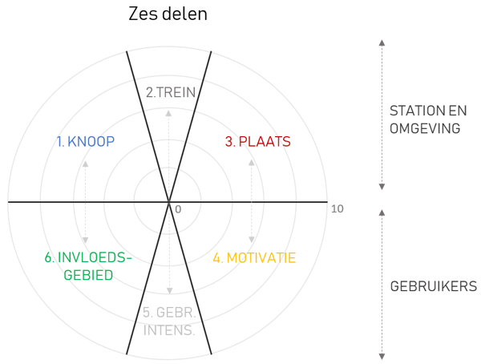

**1. KNOOP**  
Dit deel focust op de bereikbaarheid van en naar het station met verschillende vervoersmodi: met de **fiets**, per **auto** en met het **openbaar vervoer** (OV). De fiets en de auto dimensies bevatten telkens het aantal aanwezige parkeerplaatsen (data verkregen van NMBS). Indien het gedetaileerde diagram wordt geplot, wordt het onderscheid in gratis en betalende parking duidelijk. De OV-dimensie weerspiegelt hoe bereikbaar het station is per bus, tram en/of metro. Twee indicatoren zijn berekend voor de OV-haltes die zich vlakbij het station bevinden (minder dan 300 meter wandelen): 1) frequentie van de dienstregeling op een weekdag (dinsdag), en 2) het aantal unieke OV-routes die beschikbaar zijn op een weekdag (dinsdag). De OV-haltes die geselecteerd werden voor deze indicatoren kunnen weergegeven worden op kaart.

**2. TREIN**  
Het trein-deel omvat informatie over de bereikbaarheid van het station per trein. Naast de **frequentie** in dienstregeling (op een dinsdag, zaterdag en off-peak tussen 9u en 14u), wordt de **amplitude** weergegeven (dit is het dagdeel waarbinnen er treindiensten beschikbaar zijn) en worden tot slot twee **centraliteitsmaten** weergegeven. Het gaat om twee centraliteitsmaten (wij noemen ze hier ‘reistijdcentraliteit’ en ‘overstapcentraliteit’) die enkele jaren geleden ook op Vlaamse schaal berekend werden door VITO (Verachtert et al. 2016). De berekening van beide maten stoelt op de actuele geplande dienstregeling van de NMBS (verkregen via de vrij beschikbare GTFS data). De reistijdcentraliteit berekent hoe vlot je vanuit een bepaald station alle andere stations in het netwerk kunt bereiken op basis van de minimale reistijd en de frequentie van dienstverlening. De overstapcentraliteit daarentegen berekent de centraliteit in termen van het aantal overstappen die men moet nemen om vanuit een bepaald station alle andere stations in het netwerk te bereiken. Voor beide maten wordt een kleurenschaal toegewezen op basis van kwantielen, en is het mogelijk om de scores te vergelijken voor een reguliere weekdag (een dinsdag) en een weekenddag (gemiddelde zaterdag en zondag).

**3. PLAATS**  
Dit deel bevat informatie over de ruimtelijke ontwikkelingen rondom het station, in termen van: densiteit, diversiteit en design. De **densiteit** weerspiegelt ‘hoe veel’ er te doen is in de stationsbuurt en is opgesplitst in vijf indicatoren: jobdichtheid, inwonersdichtheid, en de dichtheid aan basis-, regionale en metropolitane voorzieningen. De **diversiteit** berekent hoe divers het landgebruik in de stationsbuurt is. Diversiteit kan gemeten worden in functie van de oppervlakte aan types, maar ook in functie van de ruimtelijke spreiding van deze types. Beide manieren zijn hier opgenomen in de respectieve indicatoren ‘functioneel’ en ‘ruimtelijk’. De drie types landgebruik die hiervoor werden gekarteerd zijn ‘wonen’, ‘werken’ en ‘voorzieningen. Tot slot weerspiegelt de **design** dimensie eigenschappen van de bebouwde omgeving in de stationsbuurt die volgens de ‘walkability’ literatuur belangrijk zijn voor een goed ontsloten en goed geconnecteerd bewandelbaar stratennetwerk. Drie indicatoren worden hier opgenomen: ‘interface’, ‘intersecties’ en ‘fietswandel’. De eerste heeft betrekking op de ‘interface’ tussen publieke en private ruimte in de stationsbuurt. Hoe groter deze is, hoe beter. Deze indicator werd opgemeten door de lengtes van de straatsegmenten te sommeren die langsheen de contouren van gebouwen zijn gelegen. De tweede indicator, ‘intersecties’, meet hoeveel straatintersecties (kruispunten) er zijn in de stationsbuurt, omdat deze aangeeft in hoeverre de buurt ‘permeabel’ en dus makkelijk bewandelbaar is. De laatste indicator sommeert de totale lengte aan fiets- en wandelinfrastructuur (voet- en fietspaden dus). In de tool kan voor deze drie velden kaartmateriaal gevisualiseerd worden dat rechtstreeks betrekking heeft op de totstandkoming van de scores voor deze indicatoren. Zo kan de landgebruikskaart worden geplot, die meer inzicht kan bieden in de scores voor de dimensie ‘diversiteit’, of kunnen de bushaltes worden geplot die gebruikt zijn voor de berekening van de OV-indicatoren, enz. Er is ook de mogelijkheid om bijkomende informatie te plotten (zie ‘Overige’), die niet rechtstreeks betrekking heeft op de berekeningen, maar wel relevant kan zijn tijdens de discussies (zoals de contouren van de vervoersregio’s, het netwerk van fietssnelwegen enz.).

**4. MOTIVATIE**  
Dit deel bevat informatie over de reden of motivatie waarom het station als **bestemmingsstation** wordt gebruikt. Deze data werd aangeleverd door NMBS en voorziet een vierdelige categorisering: **‘scholier’** (secundair onderwijs), **‘student’** (hoger onderwijs), **‘werk’** en **‘andere’**. De eerste drie categorieën zijn gebaseerd op abonnementsdata, terwijl de laatste categorie op losse ticketverkoop betrekking heeft.

**5. GEBRUIKERSINTENSITEIT**  
De gebruikersintensiteit reflecteert enerzijds **hoeveel mensen** op een reguliere weekdag opstappen in het station (deze eigenschap staat helemaal centraal langs de verticale as), en anderzijds reflecteert het in hoeverre het station als een **oorsprong-** (linkerkant) of als een **bestemmingsstation** (rechterkant) wordt gebruikt. Deze data werd aangeleverd door NMBS en stoelt op abonnementsdata én individuele ticketverkoop.

**6. INVLOEDSGEBIED**  
Dit laatste deel reflecteert hoe groot het invloedsgebied van het station is, en wordt berekend op basis van de **Euclidische afstand** tussen het station en de woonplaats van de abonnementshouders die het station als oorsprongstation gebruiken. Het deel is in drie dimensies opgesplitst volgens afstand: ‘wandel’ (minder dan 900 meter Euclidische afstand), ‘fiets’ (tussen 900 en 3000 meter) en ‘verder’ (alles verder dan 3000 meter). Deze data werd aangeleverd door NMBS en stoelt op abonnementsdata.